# Part II - (Ford GoBike System Data)

## by (Nimatallahi Masuud)

## Investigation Overview

> The goal is to determine the relationship between trip duration and bike share for all trips and other explanatory variables in the dataset

## Dataset Overview

> This data set includes information about individual rides made in a bike-sharing system covering the greater San Francisco Bay area..

## (1. What is the distribution of Member Gender Visualization 1)

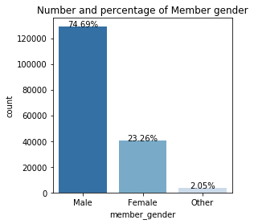

## (2. What is the distribution of User Types)

> Subscribers trips represent 90.93 % From the total trips while customer trips represent 9.07%. this shows that majority of members(user_type) are subscribers

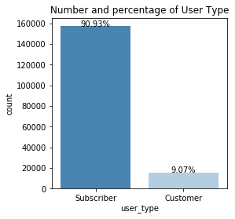

## (3. What is the distribution of bike shared for all trips)

> Users who doesn't share bike represent 90.19 % From the total trips while 9.81% represent users who share bike.

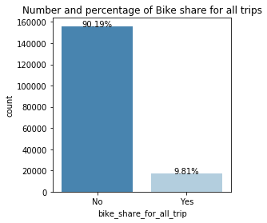

## ( 4. What is the trip distribution over weekdays)

> The distribution of both Start and End of Day of week shows that the demand for trips gradually increases from its highest levels on Thursday it then declines untill reaching its lowest levels on Saturday and Sunday. This is due to the fact that Saturday and Sunday are the weekend in the United States of America.

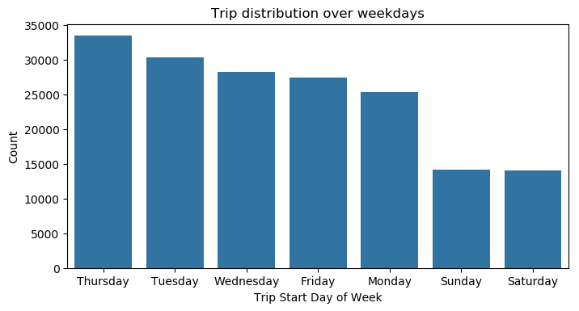

## ( 4. Relationship Between Bike Share For All Trip By User Type)

> The results belove demonstrate that only subscribers shared bikes, and no customers ever shared a bike for the entirety of a trip. Also subscribers have the highest number of no sharing of bike and since Most Users are subscribers this shows that people will be more likely to engage in the service on consistent basis and subscribe.

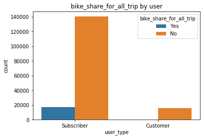

## ( 5. What Is The Most Common Days Of Week For Sharing Bike)

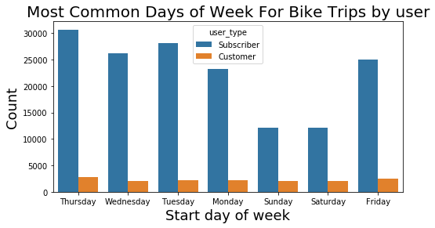

## ( 6. What is the relationship between start day of week against duration in minute with respect to user type.)

[figure not shown]